# TWD - Praca Domowa 3

Marcel Witas

24/11/2021

## Wstęp

Eksperyment miał na celu zbadanie błędów w odczytywaniu wykresów kołowych, m.in. czy rzeczywiście trudniej odczytać kąty niż długości. Zostały utworzone dwa wykresy reprezentujące te same dane (wyniki sondy) - kołowy i kolumnowy.

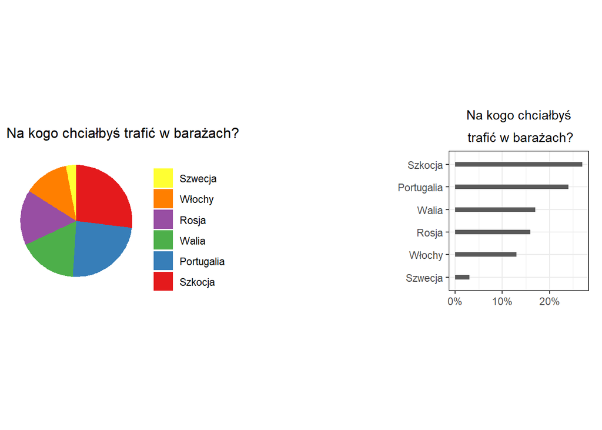

## Eksperyment

Następnie została przeprowadzona ankieta, w której wzięło udział 16 osób. Ankietowani odpowiadali na 3 pytanie dotyczące dotyczące wykresów. Ponieważ do każdego wykresu pytanie były jednakowe, wypełniający zostali poproszeni o szybkie odpowiadanie na pytania sugerując się jedynie wizualizacją, której dotyczyło pytanie. Co więcej, połowa respondentów najpierw odpowiadała na podstawie wykresu kołowego, a druga połowa przeciwnie.

##### Pytania, które zostały zadane:

1. Ile razy więcej ankietowanych zagłosowało na Szkocję niż Szwecję?
2. O ile punktów procentowych więcej było odpowiedzi na Szkocję niż Portugalię?
3. Czy większość ankietowanych chciałaby, aby Polska zagrała ze Szkocją lub Portugalią?

### Pytanie 1

Pierwsze z pytań miało sprawdzać problemy z czytaniem kątów, m.in. czy kąty rozwarte wydają się wydają się większe, a kąty ostre mniejsze, niż w rzeczywistości. Należało powiedzieć, ile razy więcej ankietowanych zagłosowało na Szkocję (27%) niż Szwecję (3%). Zatem prawidłową odpowiedzią było 9. Z wykresu kolumowego poprawnie odczytało tę informację 5 osób, a z kołowego 3. Rozkład odpowiedzi można zobaczyć na wykresie pudełkowym poniżej.

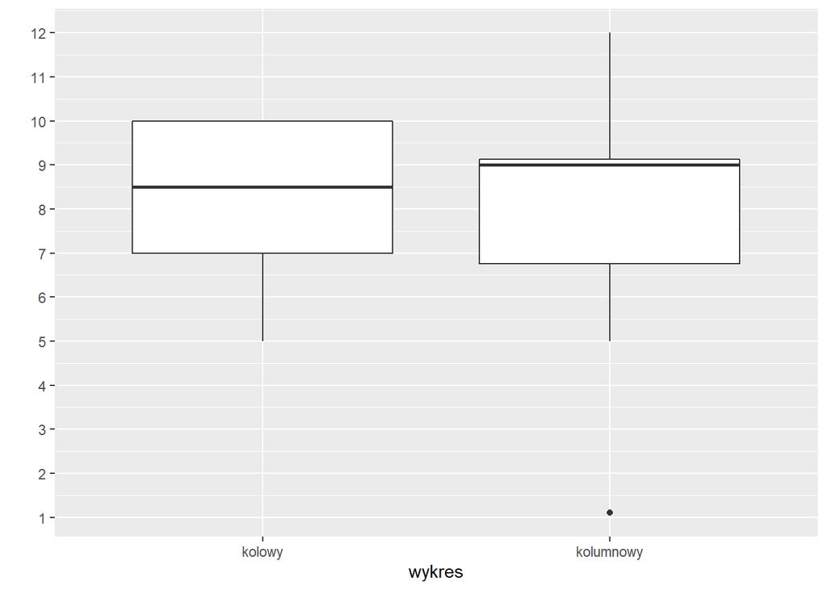

Widać, że większość odpowiedzi była z przedziału [7, 10]. Natomiast więcej skrajnych wartości obserwujemy dla wykresu kolumnowego, pojawiła się tam nawet odpowiedź 1.1, natomiast wynikała ona prawdopodobnie z niezrozumnienia pytania, aczkolwiek wartości 5 czy 12 mogą dziwić. Mediana z odpowiedzi na podstawie wykresu kolumnowego wyniosła 9, ale blisko poprawnej wartości była też mediana dla wykresu kołowego (8.5), zatem nie widać tu kolosalnej różnicy.

### Pytanie 2

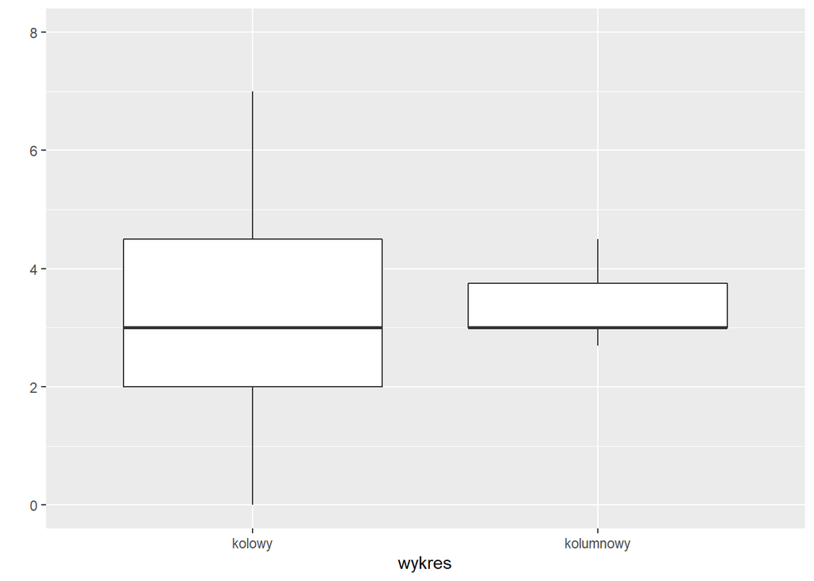

### Pytanie 3

W trzecim pytaniu, należało rostrzygnąć czy większość ankietowanych chciałaby, aby Polska zagrała ze Szkocją (27%) lub Portugalią (24%). Zatem prawidłowa odpowiedź była twierdząca. Przypuszczalnie szybciej można to odczytać z wykresu kołowego, natomiast wyniki były takie same dla obydwu wizualizacji. Pojawiło się tylko po jednej złej odpowiedzi dla każdego z wykresów.

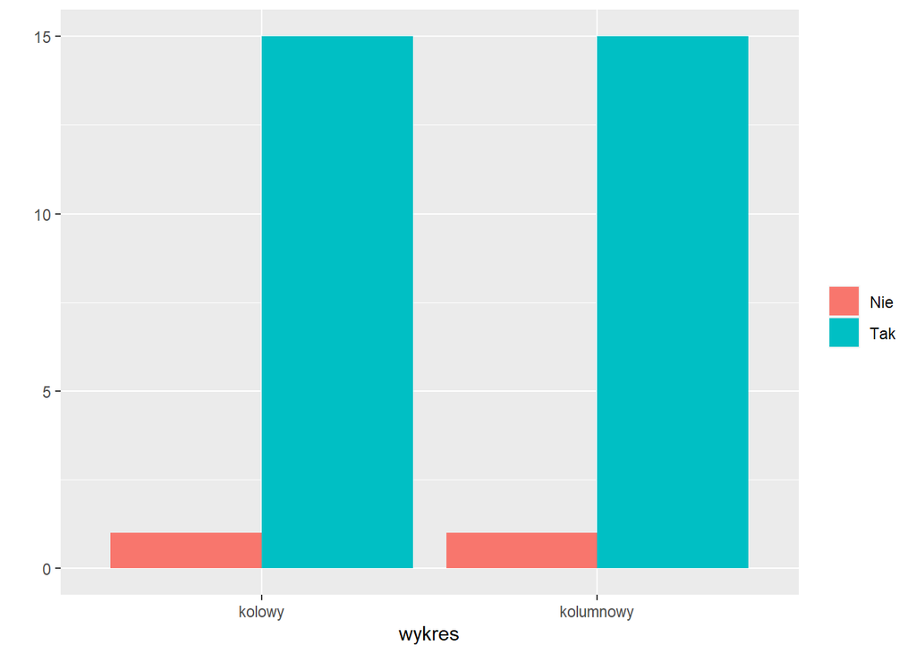

## Podsumowanie

Na koniec zadano pytanie, na podstawie którego wykresu łatwiej było udzielać odpowiedzi.

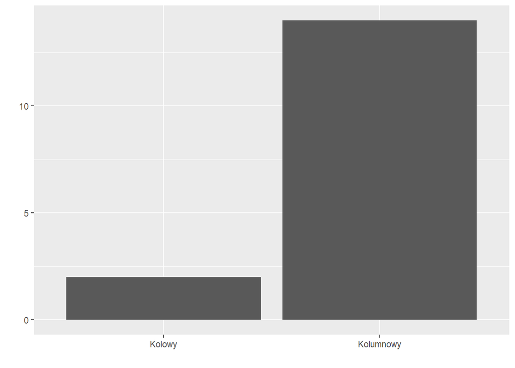

Wyniki pokazują, że dla prawie wszystkich czytelniejszy był wykres kolumnowy, czego można było się spodziewać. Kilku ankietowanych dodało, że na pytanie 3 szybciej odpowiedzieli na podstwawie wykresu kołowego.

Wykonane testy wskazują, że “dobra praktyka” mówiąca, że słupki są lepsze niż kąty, rzeczywiście działa. Wynika to szczególnie z odpowiedzi na pytanie drugie. Trudno powiedzieć, dlaczego z nie widać tego wyraźnie z pytania pierwszego, mogły mieć na to wpływ różne czynniki, jak niezbyt liczna grupa przepytanych.